# CISC520-51B Data Preprocessing I

## What is a dataframe?

### A dataframe is a data structure which stores data in rows and columns. Data analysis focused software such as R, SAS, and SPSS, use dataframes to store data in a row and column format. The most basic data frame stores a variable in each column, and the rows represent the number of observations, one row per observation. There are other ways to store data and reperesent data in dataframes which will later explore. Dataframes can be flat, a single standalone table, or relational, multiple tables related/joined by common identifiers.

### Python language has been increasingly used in data mining as it has many data-centric packages such as Numpy, Scipy, Matplotlib, and Pandas, Graphlab, Cubes... which facilitate data manipulation, analyses, and visualization. Python combined with Jupyter Notebook provide a very poweful data analysis platform. In terms of computing speed and options availability the pandas package is a joy to work with.

### Pandas which stands for "Python Data Analysis Library" is a Python library which which reads, converts, analyzes, and stores data in the Python dataframe object. Pandas analytic and visualization functionalities are built on the Numpy and Matplotlib libraries respectively. These two packages must be installed for Pandas to run successfully. Both of these poackages are included in your Anaconda installation.

### Data from diffferent sources or same source but different tables can be collated, merged, and combined to construct dataframes which we will use analytic sets.

### Now let's import pandas and explore some of its functionality:

### Pandas can read in a variety of file types such as comma and tab delimited csv files, Excel 97-2003 files, and more recent xlsx files. The pd.read_csv and pd.read_excel functions can be used to read in csv and Excel files respectively.

```python
## As mentioned we would need to impor Numpyt first
import numpy as np
import pandas as pd
```

```python
## Importing a comma delimited csv file
pd.read_csv('Safari_data.csv', delimiter=',')
```

|  | animal | uniq_id | Daily_H2O_Need |
| --- | --- | --- | --- |
| 0 | hippo | 100 | 800 |
| 1 | hippo | 101 | 700 |
| 2 | hippo | 102 | 750 |
| 3 | leopard | 103 | 335 |
| 4 | leopard | 104 | 325 |
| 5 | leopard | 105 | 320 |
| 6 | leopard | 106 | 290 |
| 7 | leopard | 107 | 310 |
| 8 | antelope | 108 | 205 |
| 9 | antelope | 109 | 215 |
| 10 | antelope | 110 | 240 |
| 11 | antelope | 111 | 225 |
| 12 | antelope | 112 | 201 |
| 13 | antelope | 113 | 95 |
| 14 | antelope | 114 | 105 |
| 15 | hyena | 115 | 420 |
| 16 | hyena | 116 | 600 |
| 17 | hyena | 117 | 500 |
| 18 | hyena | 118 | 390 |
| 19 | ostrich | 119 | 405 |
| 20 | ostrich | 120 | 415 |
| 21 | ostrich | 121 | 420 |

### The dataset contains three fields/variables, animal, unique_id, and H2O_need. Note the dataset rows are also automatically indexed from 0 to 21.

```python
pd.read_excel('BMI_Data.xls')
```

|  | Country/Region/World | ISO | Sex | Year | Mean BMI | Prevalence of BMI>=30 kg/m² (obesity) | Prevalence of BMI>=35 kg/m² (severe obesity) |
| --- | --- | --- | --- | --- | --- | --- | --- |
| 0 | United States of America | USA | Men | 1975 | 25.289004 | 0.107136 | 0.013603 |
| 1 | United States of America | USA | Men | 1976 | 25.347719 | 0.110666 | 0.014510 |
| 2 | United States of America | USA | Men | 1977 | 25.405960 | 0.114265 | 0.015477 |
| 3 | United States of America | USA | Men | 1978 | 25.465292 | 0.117944 | 0.016505 |
| 4 | United States of America | USA | Men | 1979 | 25.527234 | 0.121725 | 0.017606 |
| 5 | United States of America | USA | Men | 1980 | 25.592312 | 0.125626 | 0.018783 |
| 6 | United States of America | USA | Men | 1981 | 25.662449 | 0.129725 | 0.020064 |
| 7 | United States of America | USA | Men | 1982 | 25.737904 | 0.134047 | 0.021449 |
| 8 | United States of America | USA | Men | 1983 | 25.818297 | 0.138571 | 0.022945 |
| 9 | United States of America | USA | Men | 1984 | 25.903410 | 0.143301 | 0.024562 |
| 10 | United States of America | USA | Men | 1985 | 25.993417 | 0.148250 | 0.026308 |
| 11 | United States of America | USA | Men | 1986 | 26.087701 | 0.153409 | 0.028184 |
| 12 | United States of America | USA | Men | 1987 | 26.185576 | 0.158784 | 0.030198 |
| 13 | United States of America | USA | Men | 1988 | 26.287496 | 0.164362 | 0.032359 |
| 14 | United States of America | USA | Men | 1989 | 26.393803 | 0.170136 | 0.034679 |
| 15 | United States of America | USA | Men | 1990 | 26.504589 | 0.176103 | 0.037160 |
| 16 | United States of America | USA | Men | 1991 | 26.620734 | 0.182365 | 0.039841 |
| 17 | United States of America | USA | Men | 1992 | 26.741411 | 0.188896 | 0.042728 |
| 18 | United States of America | USA | Men | 1993 | 26.865551 | 0.195691 | 0.045818 |
| 19 | United States of America | USA | Men | 1994 | 26.992722 | 0.202720 | 0.049119 |
| 20 | United States of America | USA | Men | 1995 | 27.121533 | 0.209947 | 0.052630 |
| 21 | United States of America | USA | Men | 1996 | 27.250687 | 0.217327 | 0.056322 |
| 22 | United States of America | USA | Men | 1997 | 27.379647 | 0.224868 | 0.060197 |
| 23 | United States of America | USA | Men | 1998 | 27.507873 | 0.232511 | 0.064238 |
| 24 | United States of America | USA | Men | 1999 | 27.635375 | 0.240245 | 0.068439 |
| 25 | United States of America | USA | Men | 2000 | 27.761707 | 0.248030 | 0.072777 |
| 26 | United States of America | USA | Men | 2001 | 27.885244 | 0.255743 | 0.077199 |
| 27 | United States of America | USA | Men | 2002 | 28.004864 | 0.263361 | 0.081692 |
| 28 | United States of America | USA | Men | 2003 | 28.120228 | 0.270888 | 0.086258 |
| 29 | United States of America | USA | Men | 2004 | 28.230635 | 0.278323 | 0.090870 |
| ... | ... | ... | ... | ... | ... | ... | ... |
| 54 | United States of America | USA | Women | 1987 | 25.796414 | 0.191932 | 0.070093 |
| 55 | United States of America | USA | Women | 1988 | 25.916183 | 0.197590 | 0.073654 |
| 56 | United States of America | USA | Women | 1989 | 26.039726 | 0.203388 | 0.077355 |
| 57 | United States of America | USA | Women | 1990 | 26.167177 | 0.209333 | 0.081203 |
| 58 | United States of America | USA | Women | 1991 | 26.300210 | 0.215547 | 0.085257 |
| 59 | United States of America | USA | Women | 1992 | 26.437822 | 0.222004 | 0.089501 |
| 60 | United States of America | USA | Women | 1993 | 26.579174 | 0.228675 | 0.093924 |
| 61 | United States of America | USA | Women | 1994 | 26.723087 | 0.235549 | 0.098519 |
| 62 | United States of America | USA | Women | 1995 | 26.868630 | 0.242594 | 0.103269 |
| 63 | United States of America | USA | Women | 1996 | 27.014780 | 0.249734 | 0.108147 |
| 64 | United States of America | USA | Women | 1997 | 27.160382 | 0.256961 | 0.113125 |
| 65 | United States of America | USA | Women | 1998 | 27.303902 | 0.264217 | 0.118172 |
| 66 | United States of America | USA | Women | 1999 | 27.444786 | 0.271497 | 0.123281 |
| 67 | United States of America | USA | Women | 2000 | 27.581705 | 0.278757 | 0.128426 |
| 68 | United States of America | USA | Women | 2001 | 27.711948 | 0.285880 | 0.133531 |
| 69 | United States of America | USA | Women | 2002 | 27.835578 | 0.292858 | 0.138586 |
| 70 | United States of America | USA | Women | 2003 | 27.951670 | 0.299709 | 0.143604 |
| 71 | United States of America | USA | Women | 2004 | 28.061047 | 0.306412 | 0.148564 |
| 72 | United States of America | USA | Women | 2005 | 28.164834 | 0.312997 | 0.153479 |
| 73 | United States of America | USA | Women | 2006 | 28.263642 | 0.319474 | 0.158363 |
| 74 | United States of America | USA | Women | 2007 | 28.358604 | 0.325863 | 0.163234 |
| 75 | United States of America | USA | Women | 2008 | 28.449608 | 0.332175 | 0.168091 |
| 76 | United States of America | USA | Women | 2009 | 28.537116 | 0.338432 | 0.172940 |
| 77 | United States of America | USA | Women | 2010 | 28.620121 | 0.344648 | 0.177796 |
| 78 | United States of America | USA | Women | 2011 | 28.698262 | 0.350848 | 0.182683 |
| 79 | United States of America | USA | Women | 2012 | 28.773720 | 0.357015 | 0.187593 |
| 80 | United States of America | USA | Women | 2013 | 28.848402 | 0.363170 | 0.192545 |
| 81 | United States of America | USA | Women | 2014 | 28.922750 | 0.369330 | 0.197538 |
| 82 | United States of America | USA | Women | 2015 | 28.996657 | 0.375475 | 0.202553 |
| 83 | United States of America | USA | Women | 2016 | 29.070706 | 0.381627 | 0.207616 |

84 rows × 7 columns

### First we assign the imported dataset a variable, data, to facilitate coding.

```python
data = pd.read_excel('BMI_Data.xls')
```

### The imported dataset contains 7 variables listed below:

```python
data.head(0)
```

|  | Country/Region/World | ISO | Sex | Year | Mean BMI | Prevalence of BMI>=30 kg/m² (obesity) | Prevalence of BMI>=35 kg/m² (severe obesity) |
| --- | --- | --- | --- | --- | --- | --- | --- |

### You can specify the number of rows to be displayed by using the head function. Specifying head(0) indicates that no rows are to be displayed and the output only lists the heading which contains the variable names. If the number of rows to be displayed are not specified, head(), then by default the head function will print out the first five rows 0-4.

### The following dataset contains mean/average BMI data for every year from 1975- 2016 stratified by Sex, also annual obesity prevalence data for BMI>=30 and BMI>=53 are listed.

### The annual prevalence of obesity can be defined as the proportion of individuals in that sample who were classified as obese during that year. So in if in 1975 10/100 were obese then 0.1 is the pervalence of obesity in 1975.

```python
data.head()
```

|  | Country/Region/World | ISO | Sex | Year | Mean BMI | Prevalence of BMI>=30 kg/m² (obesity) | Prevalence of BMI>=35 kg/m² (severe obesity) |
| --- | --- | --- | --- | --- | --- | --- | --- |
| 0 | United States of America | USA | Men | 1975 | 25.289004 | 0.107136 | 0.013603 |
| 1 | United States of America | USA | Men | 1976 | 25.347719 | 0.110666 | 0.014510 |
| 2 | United States of America | USA | Men | 1977 | 25.405960 | 0.114265 | 0.015477 |
| 3 | United States of America | USA | Men | 1978 | 25.465292 | 0.117944 | 0.016505 |
| 4 | United States of America | USA | Men | 1979 | 25.527234 | 0.121725 | 0.017606 |

### You can use the tail() function to display the bottom rows, like the head function it will display the five last bottom rows if no number is specified as follows:

```python
data.tail()
```

|  | Country/Region/World | ISO | Sex | Year | Mean BMI | Prevalence of BMI>=30 kg/m² (obesity) | Prevalence of BMI>=35 kg/m² (severe obesity) |
| --- | --- | --- | --- | --- | --- | --- | --- |
| 79 | United States of America | USA | Women | 2012 | 28.773720 | 0.357015 | 0.187593 |
| 80 | United States of America | USA | Women | 2013 | 28.848402 | 0.363170 | 0.192545 |
| 81 | United States of America | USA | Women | 2014 | 28.922750 | 0.369330 | 0.197538 |
| 82 | United States of America | USA | Women | 2015 | 28.996657 | 0.375475 | 0.202553 |
| 83 | United States of America | USA | Women | 2016 | 29.070706 | 0.381627 | 0.207616 |

```python
data.tail(10)
```

|  | Country/Region/World | ISO | Sex | Year | Mean BMI | Prevalence of BMI>=30 kg/m² (obesity) | Prevalence of BMI>=35 kg/m² (severe obesity) |
| --- | --- | --- | --- | --- | --- | --- | --- |
| 74 | United States of America | USA | Women | 2007 | 28.358604 | 0.325863 | 0.163234 |
| 75 | United States of America | USA | Women | 2008 | 28.449608 | 0.332175 | 0.168091 |
| 76 | United States of America | USA | Women | 2009 | 28.537116 | 0.338432 | 0.172940 |
| 77 | United States of America | USA | Women | 2010 | 28.620121 | 0.344648 | 0.177796 |
| 78 | United States of America | USA | Women | 2011 | 28.698262 | 0.350848 | 0.182683 |
| 79 | United States of America | USA | Women | 2012 | 28.773720 | 0.357015 | 0.187593 |
| 80 | United States of America | USA | Women | 2013 | 28.848402 | 0.363170 | 0.192545 |
| 81 | United States of America | USA | Women | 2014 | 28.922750 | 0.369330 | 0.197538 |
| 82 | United States of America | USA | Women | 2015 | 28.996657 | 0.375475 | 0.202553 |
| 83 | United States of America | USA | Women | 2016 | 29.070706 | 0.381627 | 0.207616 |

### We can find out the dataset shape that is the total number of rows and columns by using the shape function:

```python
data.shape
```

```
(84, 7)
```

### The above output indicates that the dataset, data, has 84 rows and 7 columns. If a dataset has more rows than columns then it is referred to as a vertical dataset. If it has more columns than rows then it is referred to as a wide/horizointal dataset.

### The head and tail funtions work well for displaying the upper and bottom rows, but what if we need to just display as set of rows located in the middle for example, rows 30 to 40? This can be achieved using the loc[] function as follows:

```python
data.loc[30:40,:]
```

|  | Country/Region/World | ISO | Sex | Year | Mean BMI | Prevalence of BMI>=30 kg/m² (obesity) | Prevalence of BMI>=35 kg/m² (severe obesity) |
| --- | --- | --- | --- | --- | --- | --- | --- |
| 30 | United States of America | USA | Men | 2005 | 28.334788 | 0.285671 | 0.095526 |
| 31 | United States of America | USA | Men | 2006 | 28.433046 | 0.292944 | 0.100229 |
| 32 | United States of America | USA | Men | 2007 | 28.524040 | 0.300161 | 0.104988 |
| 33 | United States of America | USA | Men | 2008 | 28.607092 | 0.307332 | 0.109810 |
| 34 | United States of America | USA | Men | 2009 | 28.680926 | 0.314480 | 0.114693 |
| 35 | United States of America | USA | Men | 2010 | 28.744276 | 0.321614 | 0.119653 |
| 36 | United States of America | USA | Men | 2011 | 28.798413 | 0.328731 | 0.124690 |
| 37 | United States of America | USA | Men | 2012 | 28.845012 | 0.335865 | 0.129825 |
| 38 | United States of America | USA | Men | 2013 | 28.887995 | 0.343023 | 0.135061 |
| 39 | United States of America | USA | Men | 2014 | 28.929397 | 0.350212 | 0.140412 |
| 40 | United States of America | USA | Men | 2015 | 28.971172 | 0.357449 | 0.145907 |

### The loc function can also be used to display the first 5 rows emulating the default head() output as follows:

```python
data.loc[0:4,:]
```

|  | Country/Region/World | ISO | Sex | Year | Mean BMI | Prevalence of BMI>=30 kg/m² (obesity) | Prevalence of BMI>=35 kg/m² (severe obesity) |
| --- | --- | --- | --- | --- | --- | --- | --- |
| 0 | United States of America | USA | Men | 1975 | 25.289004 | 0.107136 | 0.013603 |
| 1 | United States of America | USA | Men | 1976 | 25.347719 | 0.110666 | 0.014510 |
| 2 | United States of America | USA | Men | 1977 | 25.405960 | 0.114265 | 0.015477 |
| 3 | United States of America | USA | Men | 1978 | 25.465292 | 0.117944 | 0.016505 |
| 4 | United States of America | USA | Men | 1979 | 25.527234 | 0.121725 | 0.017606 |

### In the above examples we learned how to manipulate the display of rows, we can also specify which columns to display by using the iloc[] function, the following code specifies the display of the fourth column, Year:

```python
data.iloc[:,3]
```

```
0     1975
1     1976
2     1977
3     1978
4     1979
5     1980
6     1981
7     1982
8     1983
9     1984
10    1985
11    1986
12    1987
13    1988
14    1989
```

[output cut: 47 more lines]

### The same can be achieved by using the column name as follows:

```python
data.loc[:,'Year']
```

```
0     1975
1     1976
2     1977
3     1978
4     1979
5     1980
6     1981
7     1982
8     1983
9     1984
10    1985
11    1986
12    1987
13    1988
14    1989
```

[output cut: 47 more lines]

### The easiest way to display a column is just to list its name in square brackets just like we would in a dictionary as follows:

```python
data[['Year']]
```

|  | Year |
| --- | --- |
| 0 | 1975 |
| 1 | 1976 |
| 2 | 1977 |
| 3 | 1978 |
| 4 | 1979 |
| 5 | 1980 |
| 6 | 1981 |
| 7 | 1982 |
| 8 | 1983 |
| 9 | 1984 |
| 10 | 1985 |
| 11 | 1986 |
| 12 | 1987 |
| 13 | 1988 |
| 14 | 1989 |
| 15 | 1990 |
| 16 | 1991 |
| 17 | 1992 |
| 18 | 1993 |
| 19 | 1994 |
| 20 | 1995 |
| 21 | 1996 |
| 22 | 1997 |
| 23 | 1998 |
| 24 | 1999 |
| 25 | 2000 |
| 26 | 2001 |
| 27 | 2002 |
| 28 | 2003 |
| 29 | 2004 |
| ... | ... |
| 54 | 1987 |
| 55 | 1988 |
| 56 | 1989 |
| 57 | 1990 |
| 58 | 1991 |
| 59 | 1992 |
| 60 | 1993 |
| 61 | 1994 |
| 62 | 1995 |
| 63 | 1996 |
| 64 | 1997 |
| 65 | 1998 |
| 66 | 1999 |
| 67 | 2000 |
| 68 | 2001 |
| 69 | 2002 |
| 70 | 2003 |
| 71 | 2004 |
| 72 | 2005 |
| 73 | 2006 |
| 74 | 2007 |
| 75 | 2008 |
| 76 | 2009 |
| 77 | 2010 |
| 78 | 2011 |
| 79 | 2012 |
| 80 | 2013 |
| 81 | 2014 |
| 82 | 2015 |
| 83 | 2016 |

84 rows × 1 columns

### We can also specify the display of multiple columns as follows:

```python
data[["Year", "Mean BMI"]]
```

|  | Year | Mean BMI |
| --- | --- | --- |
| 0 | 1975 | 25.289004 |
| 1 | 1976 | 25.347719 |
| 2 | 1977 | 25.405960 |
| 3 | 1978 | 25.465292 |
| 4 | 1979 | 25.527234 |
| 5 | 1980 | 25.592312 |
| 6 | 1981 | 25.662449 |
| 7 | 1982 | 25.737904 |
| 8 | 1983 | 25.818297 |
| 9 | 1984 | 25.903410 |
| 10 | 1985 | 25.993417 |
| 11 | 1986 | 26.087701 |
| 12 | 1987 | 26.185576 |
| 13 | 1988 | 26.287496 |
| 14 | 1989 | 26.393803 |
| 15 | 1990 | 26.504589 |
| 16 | 1991 | 26.620734 |
| 17 | 1992 | 26.741411 |
| 18 | 1993 | 26.865551 |
| 19 | 1994 | 26.992722 |
| 20 | 1995 | 27.121533 |
| 21 | 1996 | 27.250687 |
| 22 | 1997 | 27.379647 |
| 23 | 1998 | 27.507873 |
| 24 | 1999 | 27.635375 |
| 25 | 2000 | 27.761707 |
| 26 | 2001 | 27.885244 |
| 27 | 2002 | 28.004864 |
| 28 | 2003 | 28.120228 |
| 29 | 2004 | 28.230635 |
| ... | ... | ... |
| 54 | 1987 | 25.796414 |
| 55 | 1988 | 25.916183 |
| 56 | 1989 | 26.039726 |
| 57 | 1990 | 26.167177 |
| 58 | 1991 | 26.300210 |
| 59 | 1992 | 26.437822 |
| 60 | 1993 | 26.579174 |
| 61 | 1994 | 26.723087 |
| 62 | 1995 | 26.868630 |
| 63 | 1996 | 27.014780 |
| 64 | 1997 | 27.160382 |
| 65 | 1998 | 27.303902 |
| 66 | 1999 | 27.444786 |
| 67 | 2000 | 27.581705 |
| 68 | 2001 | 27.711948 |
| 69 | 2002 | 27.835578 |
| 70 | 2003 | 27.951670 |
| 71 | 2004 | 28.061047 |
| 72 | 2005 | 28.164834 |
| 73 | 2006 | 28.263642 |
| 74 | 2007 | 28.358604 |
| 75 | 2008 | 28.449608 |
| 76 | 2009 | 28.537116 |
| 77 | 2010 | 28.620121 |
| 78 | 2011 | 28.698262 |
| 79 | 2012 | 28.773720 |
| 80 | 2013 | 28.848402 |
| 81 | 2014 | 28.922750 |
| 82 | 2015 | 28.996657 |
| 83 | 2016 | 29.070706 |

84 rows × 2 columns

### We can specify that the first five rows of teh specified columns be displayed as follows:

```python
data[["Year", "Mean BMI"]].head()
```

|  | Year | Mean BMI |
| --- | --- | --- |
| 0 | 1975 | 25.289004 |
| 1 | 1976 | 25.347719 |
| 2 | 1977 | 25.405960 |
| 3 | 1978 | 25.465292 |
| 4 | 1979 | 25.527234 |

### The loc function can also be used along with the columns specification to control the number of rows to be displayed as follows:

```python
data[["Year", "Mean BMI"]].loc[5:10,:]
```

|  | Year | Mean BMI |
| --- | --- | --- |
| 5 | 1980 | 25.592312 |
| 6 | 1981 | 25.662449 |
| 7 | 1982 | 25.737904 |
| 8 | 1983 | 25.818297 |
| 9 | 1984 | 25.903410 |
| 10 | 1985 | 25.993417 |

### Each column in the dataframe represents a series object. This object has name, length, and data type attributes.

```python
type(data['Year'])
```

```
pandas.core.series.Series
```

### A dataframe can contain series with different data types, string, int64, float...

### We can also use other statistical and mathematical methods on the series or the entire dataframe as follows:

```python
data[["Mean BMI","Year"]].mean()
```

```
Mean BMI      27.05512
Year        1995.50000
dtype: float64
```

### So the average mean BMI across the years from 1975-2016 is ~27.1 which is >25 then considered overweight.

### You can also get the mean for all the numeric variables in the dataframe as follows:

```python
data.mean()
```

```
Year                                            1995.500000
Mean BMI                                          27.055120
Prevalence of BMI>=30 kg/m² (obesity)              0.236672
Prevalence of BMI>=35 kg/m² (severe obesity)       0.088666
dtype: float64
```

### Another useful statistical method is the correlation between tow numeric variables, which is basically the amount that two variables increase or decrease in parallel to each other. That is if everytime temperature increased by a single degree humidity increases by a factor of 2 we can say that the two numeric variables are perfectly correlated, and their correlation would be one. If this only ahppens 50% of the time then their correlation would be 0.5, if everytime temp increased by 1 the humidity decreased by a factor of 2 then we would say that they are perfectly negatively correlated and their correlation would be -1. A correlation ranges from -1 to 1.

### You can run a correlation bwtween two columns/variables as follows:

```python
data[["Mean BMI","Year"]].corr()
```

|  | Mean BMI | Year |
| --- | --- | --- |
| Mean BMI | 1.000000 | 0.988874 |
| Year | 0.988874 | 1.000000 |

### Here we note that Year and Mean BMI are highly correlated which means as the year increases the mean BMI is increasing.

### You can also run a correlation on the entire data frame as follows:

```python
data.corr()
```

|  | Year | Mean BMI | Prevalence of BMI>=30 kg/m² (obesity) | Prevalence of BMI>=35 kg/m² (severe obesity) |
| --- | --- | --- | --- | --- |
| Year | 1.000000 | 0.988874 | 0.979017 | 0.879833 |
| Mean BMI | 0.988874 | 1.000000 | 0.950525 | 0.831829 |
| Prevalence of BMI>=30 kg/m² (obesity) | 0.979017 | 0.950525 | 1.000000 | 0.951780 |
| Prevalence of BMI>=35 kg/m² (severe obesity) | 0.879833 | 0.831829 | 0.951780 | 1.000000 |

### Here we note that Year, MEAn BMI, and obesity>=30 and obesity>=35 are all positively correlated which amkes sense.

### Other useful statistical methods we can apply are the standard deviation ,std, min, max, and median as follows:

```python
data.std()
```

```
Year                                            12.193718
Mean BMI                                         1.348442
Prevalence of BMI>=30 kg/m² (obesity)            0.079637
Prevalence of BMI>=35 kg/m² (severe obesity)     0.053498
dtype: float64
```

```python
data.min()
```

```
Country/Region/World                            United States of America
ISO                                                                  USA
Sex                                                                  Men
Year                                                                1975
Mean BMI                                                         24.7196
Prevalence of BMI>=30 kg/m² (obesity)                           0.107136
Prevalence of BMI>=35 kg/m² (severe obesity)                   0.0136026
dtype: object
```

```python
data.max()
```

```
Country/Region/World                            United States of America
ISO                                                                  USA
Sex                                                                Women
Year                                                                2016
Mean BMI                                                         29.0707
Prevalence of BMI>=30 kg/m² (obesity)                           0.381627
Prevalence of BMI>=35 kg/m² (severe obesity)                    0.207616
dtype: object
```

```python
data.median()
```

```
Year                                            1995.500000
Mean BMI                                          27.068156
Prevalence of BMI>=30 kg/m² (obesity)              0.230593
Prevalence of BMI>=35 kg/m² (severe obesity)       0.079279
dtype: float64
```

## Application of Mathematical Methods to Data:

### Mathematical operations can be directly performed on the data series or the entire data frame, for example suppose we want to convert the mean obesity prevalence per year to the mean % obesity prevalence by multiplyting all the obesity prevalence observations by 100 as follows:

```python
data["Prevalence of BMI>=30 kg/m² (obesity)"]*100
```

```
0     10.713612
1     11.066610
2     11.426480
3     11.794365
4     12.172458
5     12.562636
6     12.972531
7     13.404742
8     13.857057
9     14.330123
10    14.825045
11    15.340942
12    15.878398
13    16.436217
14    17.013618
```

[output cut: 47 more lines]

## Filtering Using Boolean Logic in Pandas:

### The mean for the prevalence of obesity>=30 is around 0.2, let's say we want to filter out all the obesity prevalence observations which are above the mean, we can do that as follows:

```python
BMI_filter=data["Prevalence of BMI>=30 kg/m² (obesity)"]>0.2
BMI_filter
```

```
0     False
1     False
2     False
3     False
4     False
5     False
6     False
7     False
8     False
9     False
10    False
11    False
12    False
13    False
14    False
```

[output cut: 47 more lines]

### Now that the Boolean evaluation has been implemented we can use this evaluation to select rows/observations which evaluate as 'True' as follows:

```python
filtered_data = data[BMI_filter]
filtered_data
```

|  | Country/Region/World | ISO | Sex | Year | Mean BMI | Prevalence of BMI>=30 kg/m² (obesity) | Prevalence of BMI>=35 kg/m² (severe obesity) |
| --- | --- | --- | --- | --- | --- | --- | --- |
| 19 | United States of America | USA | Men | 1994 | 26.992722 | 0.202720 | 0.049119 |
| 20 | United States of America | USA | Men | 1995 | 27.121533 | 0.209947 | 0.052630 |
| 21 | United States of America | USA | Men | 1996 | 27.250687 | 0.217327 | 0.056322 |
| 22 | United States of America | USA | Men | 1997 | 27.379647 | 0.224868 | 0.060197 |
| 23 | United States of America | USA | Men | 1998 | 27.507873 | 0.232511 | 0.064238 |
| 24 | United States of America | USA | Men | 1999 | 27.635375 | 0.240245 | 0.068439 |
| 25 | United States of America | USA | Men | 2000 | 27.761707 | 0.248030 | 0.072777 |
| 26 | United States of America | USA | Men | 2001 | 27.885244 | 0.255743 | 0.077199 |
| 27 | United States of America | USA | Men | 2002 | 28.004864 | 0.263361 | 0.081692 |
| 28 | United States of America | USA | Men | 2003 | 28.120228 | 0.270888 | 0.086258 |
| 29 | United States of America | USA | Men | 2004 | 28.230635 | 0.278323 | 0.090870 |
| 30 | United States of America | USA | Men | 2005 | 28.334788 | 0.285671 | 0.095526 |
| 31 | United States of America | USA | Men | 2006 | 28.433046 | 0.292944 | 0.100229 |
| 32 | United States of America | USA | Men | 2007 | 28.524040 | 0.300161 | 0.104988 |
| 33 | United States of America | USA | Men | 2008 | 28.607092 | 0.307332 | 0.109810 |
| 34 | United States of America | USA | Men | 2009 | 28.680926 | 0.314480 | 0.114693 |
| 35 | United States of America | USA | Men | 2010 | 28.744276 | 0.321614 | 0.119653 |
| 36 | United States of America | USA | Men | 2011 | 28.798413 | 0.328731 | 0.124690 |
| 37 | United States of America | USA | Men | 2012 | 28.845012 | 0.335865 | 0.129825 |
| 38 | United States of America | USA | Men | 2013 | 28.887995 | 0.343023 | 0.135061 |
| 39 | United States of America | USA | Men | 2014 | 28.929397 | 0.350212 | 0.140412 |
| 40 | United States of America | USA | Men | 2015 | 28.971172 | 0.357449 | 0.145907 |
| 41 | United States of America | USA | Men | 2016 | 29.013220 | 0.364743 | 0.151533 |
| 56 | United States of America | USA | Women | 1989 | 26.039726 | 0.203388 | 0.077355 |
| 57 | United States of America | USA | Women | 1990 | 26.167177 | 0.209333 | 0.081203 |
| 58 | United States of America | USA | Women | 1991 | 26.300210 | 0.215547 | 0.085257 |
| 59 | United States of America | USA | Women | 1992 | 26.437822 | 0.222004 | 0.089501 |
| 60 | United States of America | USA | Women | 1993 | 26.579174 | 0.228675 | 0.093924 |
| 61 | United States of America | USA | Women | 1994 | 26.723087 | 0.235549 | 0.098519 |
| 62 | United States of America | USA | Women | 1995 | 26.868630 | 0.242594 | 0.103269 |
| 63 | United States of America | USA | Women | 1996 | 27.014780 | 0.249734 | 0.108147 |
| 64 | United States of America | USA | Women | 1997 | 27.160382 | 0.256961 | 0.113125 |
| 65 | United States of America | USA | Women | 1998 | 27.303902 | 0.264217 | 0.118172 |
| 66 | United States of America | USA | Women | 1999 | 27.444786 | 0.271497 | 0.123281 |
| 67 | United States of America | USA | Women | 2000 | 27.581705 | 0.278757 | 0.128426 |
| 68 | United States of America | USA | Women | 2001 | 27.711948 | 0.285880 | 0.133531 |
| 69 | United States of America | USA | Women | 2002 | 27.835578 | 0.292858 | 0.138586 |
| 70 | United States of America | USA | Women | 2003 | 27.951670 | 0.299709 | 0.143604 |
| 71 | United States of America | USA | Women | 2004 | 28.061047 | 0.306412 | 0.148564 |
| 72 | United States of America | USA | Women | 2005 | 28.164834 | 0.312997 | 0.153479 |
| 73 | United States of America | USA | Women | 2006 | 28.263642 | 0.319474 | 0.158363 |
| 74 | United States of America | USA | Women | 2007 | 28.358604 | 0.325863 | 0.163234 |
| 75 | United States of America | USA | Women | 2008 | 28.449608 | 0.332175 | 0.168091 |
| 76 | United States of America | USA | Women | 2009 | 28.537116 | 0.338432 | 0.172940 |
| 77 | United States of America | USA | Women | 2010 | 28.620121 | 0.344648 | 0.177796 |
| 78 | United States of America | USA | Women | 2011 | 28.698262 | 0.350848 | 0.182683 |
| 79 | United States of America | USA | Women | 2012 | 28.773720 | 0.357015 | 0.187593 |
| 80 | United States of America | USA | Women | 2013 | 28.848402 | 0.363170 | 0.192545 |
| 81 | United States of America | USA | Women | 2014 | 28.922750 | 0.369330 | 0.197538 |
| 82 | United States of America | USA | Women | 2015 | 28.996657 | 0.375475 | 0.202553 |
| 83 | United States of America | USA | Women | 2016 | 29.070706 | 0.381627 | 0.207616 |

```python
filter2 = (data["Prevalence of BMI>=30 kg/m² (obesity)"]>0.2) & (data["Sex"] == "Men")
filtered_data2 = data[filter2]
filtered_data2.head()
```

|  | Country/Region/World | ISO | Sex | Year | Mean BMI | Prevalence of BMI>=30 kg/m² (obesity) | Prevalence of BMI>=35 kg/m² (severe obesity) |
| --- | --- | --- | --- | --- | --- | --- | --- |
| 19 | United States of America | USA | Men | 1994 | 26.992722 | 0.202720 | 0.049119 |
| 20 | United States of America | USA | Men | 1995 | 27.121533 | 0.209947 | 0.052630 |
| 21 | United States of America | USA | Men | 1996 | 27.250687 | 0.217327 | 0.056322 |
| 22 | United States of America | USA | Men | 1997 | 27.379647 | 0.224868 | 0.060197 |
| 23 | United States of America | USA | Men | 1998 | 27.507873 | 0.232511 | 0.064238 |

## Data Visualization with Pandas

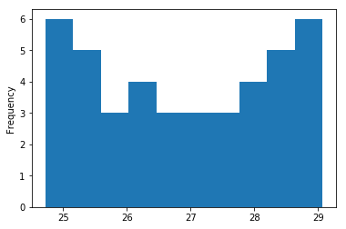

```python
%matplotlib inline
data[data["Sex"] == "Women"]["Mean BMI"].plot(kind="hist")
```

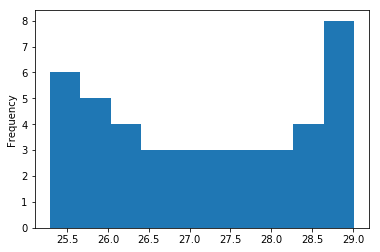

```python
%matplotlib inline
data[data["Sex"] == "Men"]["Mean BMI"].plot(kind="hist")
```

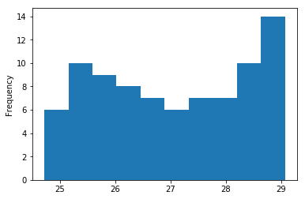

```python
%matplotlib inline
data["Mean BMI"].plot(kind="hist")
```

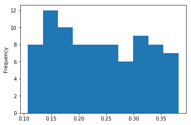

```python
%matplotlib inline
data["Prevalence of BMI>=30 kg/m² (obesity)"].plot(kind="hist")
```

## Homework Exercises:

### Download the posted SA_Obesity_Lancet_Data xlsx formatted dataset which is posted under the lesson folder on Moodle.

### 1- Import to pandas to create a pandas dataframe

### 2- Display the last 10 rows/observations

### 3- Display the first two columns, Sex and Year for the rows/observations 10-25

### 4- Calculate the correlation between Year and Mean_BMI and interpret the finding

### 5- Plot a histogram for Prevalence_BMI_over_40_morbid_obese for Women only.